# Corporate Finance

Lecture 3: The Efficient Frontier and the Best Portfolio

Camilo Saldarriaga

Finance Department, ESCP Business School, 2026/2027

## Plan

- Recap from lecture 2
- Find the efficient portfolios built from two stocks
- Move from two stocks to many: the efficient frontier
- Add a risk-free asset and identify the single best risky portfolio: The “super-efficient” portfolio
- Separate the risk that diversification removes from the risk that stays

Mostly based on the BDM textbook Chap. 11.2-5.

Recap lecture 2

## Recap: portfolio choice, in what to invest?

- You have money to invest and many assets to choose from. A **portfolio** is the answer to one question: how much of the money goes into each asset?
- We start the analysis with only 2 assets, but we will extend it.
- Formally, we answer this question by choosing the weights $x_{1}$ and $x_{2}$: the percentage of the portfolio we invest in each asset, with $x_{1} + x_{2} = 1$.
- Two assets held together are not the same thing as each asset on its own: the portfolio’s risk depends on how the assets move relative to each other.
- Lecture 2 built the tools to describe any portfolio by its expected return and its risk.

## Recap: the mean-variance framework

- Investors care about two things: **expected return** (more is better) and **risk**, measured by the variance or its square root, the standard deviation (less is better).
- Every asset is a point on a chart with risk on the horizontal axis and expected return on the vertical axis.

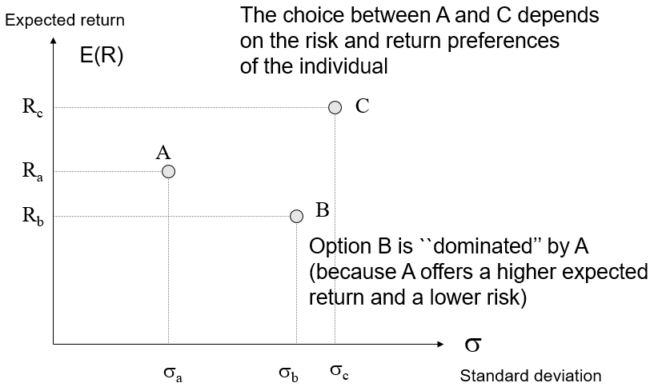

- The mean variance framework is defined by two equivalent rules: for a given return, minimise risk; for a given risk, maximise return.

## Recap: the utility function

- The trade-off between return and risk is written as a **utility function**: a score of how satisfied an investor is with a risky investment. We model investors behavior as if they act to maximize this function.

  $$U = E(W) - \frac{\gamma}{2}\,\text{Var}(W)$$
- $E(W)$ is the expected final wealth and $\text{Var}(W)$ its variance. The score rises with the mean and falls with the variance.
- Remember that wealth $W$ is a **random variable**: it is uncertain, we do not know the result of the investment before we invest. We can only characterize its past behaviour with the mean and the variance.
- $\gamma > 0$ is the **risk aversion**: A higher $\gamma$ means a more cautious investor.

## Recap: the three monsters

| Measure | Formula | What it tells us | Range |
| --- | --- | --- | --- |
| Covariance | $\sigma_{X,Y}$ | Do $X$ and $Y$ move together? | any number |
| Correlation | $\sigma_{X,Y} / (\sigma_{X}\sigma_{Y})$ | How strongly, on a fixed scale | $-1$ to $+1$ |
| Beta | $\sigma_{X,Y} / \sigma_{X}^{2}$ | How much $Y$ moves when $X$ moves 1% | any number |

- All three are built from the covariance: for each year, the distance of $X$ from its mean times the distance of $Y$ from its mean, averaged.

  $$\text{Cov}\left(R_{i},R_{j}\right) = \frac{1}{T-1} \sum^{T}_{t=1}\left(R_{it} - \overline{R}_{i}\right)\left(R_{jt} - \overline{R}_{j}\right)$$
- Positive: they tend to move together. Negative: in opposite directions.

## Recap: correlation and beta

- **Correlation**: the covariance divided by the two volatilities. The units cancel, so the result always lies between $-1$ and $+1$.

  $$\rho_{X,Y} = \text{Corr}\left(R_{i},R_{j}\right) = \frac{\text{Cov}\left(R_{i},R_{j}\right)}{\sigma_{R_{i}}\,\sigma_{R_{j}}}$$

  $+1$: always move together. $0$: no systematic link. $-1$: always in opposite directions.
- **Beta**: the covariance divided by the variance of $X$, the one that does the moving. It answers: when $X$ moves by 1%, by how much does $Y$ move on average?

  $$\beta_{Y,X} = \frac{\text{Cov}\left(X,Y\right)}{\text{Var}\left(X\right)} = \frac{\sigma_{X,Y}}{\sigma_{X}^{2}}$$

  A beta of 1.5 with respect to the market: a market rise of 1% comes with a rise of about 1.5% for the stock.

## Recap: portfolio return

**The portfolio return**

- The **weights** $x_{1}, x_{2}$ are the fractions of the money in each stock; they add up to 1.
- The portfolio return is the **weighted average of the individual returns**: each stock’s return counts in proportion to the money invested in it.

  $$R_{p} = x_{1}R_{1} + x_{2}R_{2}$$
- Example: 30% in stock 1 and 70% in stock 2, with returns of 10% and 4%, gives $R_{p} = 0.3 \times 10\% + 0.7 \times 4\% = 5.8\%$.

## Recap: portfolio variance and volatility

- Risk does not add up the same way. The variance of the portfolio is

  $$\text{Var}\left(R_{p}\right) = \underbrace{x_{1}^{2}\text{Var}\left(R_{1}\right) + x_{2}^{2}\text{Var}\left(R_{2}\right)}_{\text{individual risks}} + \underbrace{2x_{1}x_{2}\text{Cov}\left(R_{1},R_{2}\right)}_{\text{comovement}}$$
- The comovement term is what makes a portfolio different from the sum of its parts. The volatility is $\sigma_{R_{p}} = \sqrt{\text{Var}\left(R_{p}\right)}$.
- Since the covariance is the correlation times the two volatilities, $\text{Cov}\left(R_{1},R_{2}\right) = \rho_{12}\,\sigma_{1}\,\sigma_{2}$, the same variance can be written with the correlation:

  $$\text{Var}\left(R_{p}\right) = x_{1}^{2}\sigma_{1}^{2} + x_{2}^{2}\sigma_{2}^{2} + 2x_{1}x_{2}\,\rho_{12}\,\sigma_{1}\,\sigma_{2}$$

  This is the form that shows how the correlation drives the risk of the portfolio (next slide).

## Recap: correlation drives diversification

The correlation term defines how strong the diversification effect will be.

**Correlation = 1**. There is no diversification: the portfolio’s risk is just the weighted average of the two risks.

**Correlation below 1 (including zero)**. The portfolio’s risk is **smaller than the average risk** of the individual assets. There is diversification.

**The stocks tend to move in opposite directions** (negative correlation). A move in one is usually offset by a move in the other, so diversification is strongest here. In the extreme case of a correlation of −1 the risks subtract exactly, and with the right weights the portfolio’s risk can be brought down to zero.

Beginning of lecture 3 content

Lecture 2 gave us the tools to measure the return and the risk of any portfolio. Today we use them to answer the real question: among all the portfolios we could build, which ones are worth holding?

## A. Efficient portfolios with two stocks

| Stock | Expected return | Volatility |
| --- | --- | --- |
| Intel | 26% | 50% |
| Coca-Cola | 6% | 25% |

- We assume that the correlation between the two stocks is zero.
  - Which portfolio should we choose?

## Efficient portfolios with two stocks (con’t 2)

- Which portfolio should we choose?
- Example: portfolio invested to 40% in Intel and 60% in Coca-Cola.

$$\begin{aligned}
E\left[R_{40-60}\right]& = x_{I} E\left[R_{I}\right] + x_{C} E\left[R_{C}\right] = 0.4\times 0.26 + 0.6 \times 0.06 = 0.14 \\
& \\
\text{Var}\left[R_{40-60}\right] & = x_{I}^{2} \text{Var}\left[R_{I}\right]+x_{C}^{2} \text{Var}\left[R_{C}\right]+2x_{I}x_{C}Corr\left(R_{I}, R_{C}\right) \sigma_{I} \sigma_{C} \\
& = 0.4^{2} \times 0.5^{2} + 0.6^{2} \times 0.25^{2}+0 \\
& = 0.0625 \\
& \\
\sigma_{40-60} & = \sqrt{0.0625} = 25\%
\end{aligned}$$

## Efficient portfolios with two stocks (con’t 3)

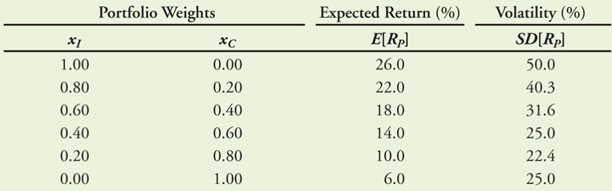

Expected returns and volatility for different portfolios of two stocks.

## From the table to the frontier

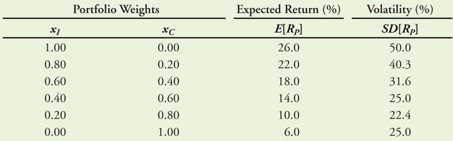

Each row is one portfolio; plotted as points they trace the curve of all two-stock portfolios, whose upper part is the **efficient** set.

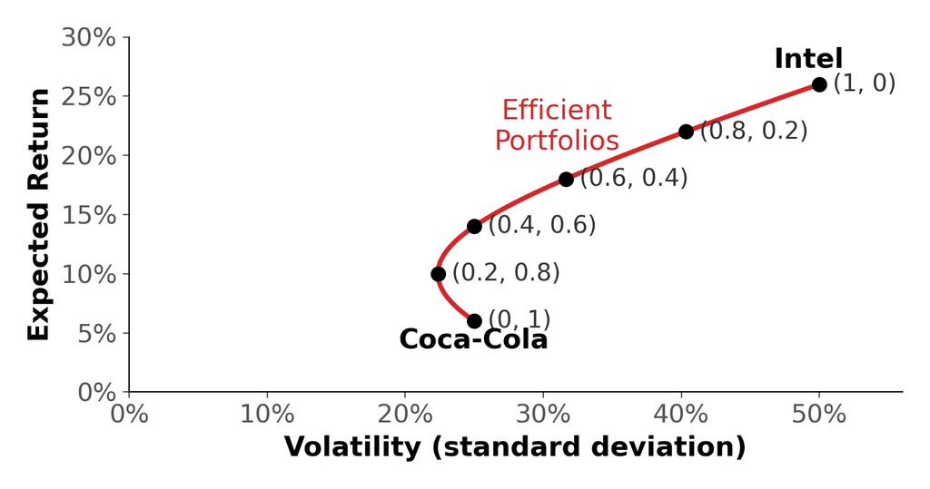

## Efficient portfolios

- We define as efficient, all portfolios with:
  - Minimum variance for a given expected return;
  - Maximum expected return for a given variance.
- A portfolio is **INefficient** when it is possible to find another portfolio which has a larger expected return and a lower or equal volatility.
- To know if a portfolio is efficient we ask **two** questions: is there a portfolio witht the same return but lower risk? is there one with the same risk but higher return?
- Hence: investors who simultaneously maximise the expected return on their portfolio and minimise risk, will choose an efficient portfolio.

## Same risk, more return?

**If I hold the portfolio (0, 1), all in Coca-Cola, is there a portfolio with the same volatility but a higher return?**

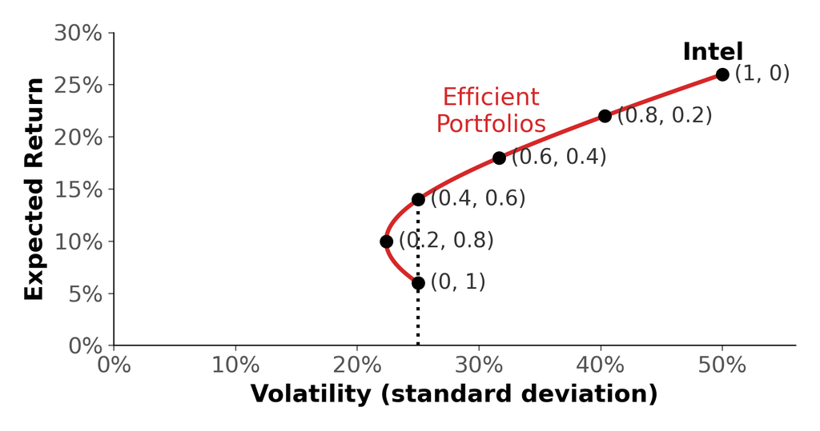

Follow the dotted line up from 25% volatility: it meets the curve twice.

## The efficient frontier for two stocks

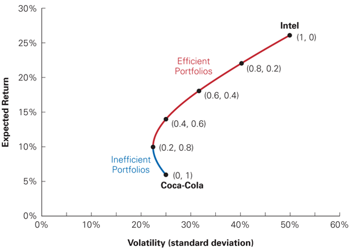

## The effect of correlation

- How much risk you remove by combining two assets depends on their correlation, and that is what shapes the frontier.
- **Correlation +1**: risk is a weighted average of the two volatilities. The frontier is a straight line: no diversification.
- **Lower correlation**: the curve bends to the left, the same returns at lower risk. The gain is largest for negative correlation, and maximal at $-1$.

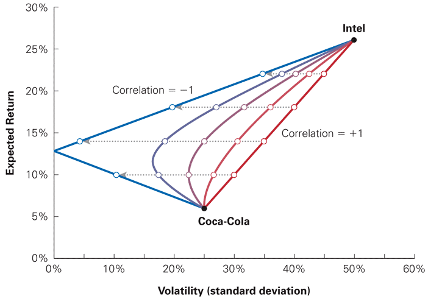

## The effect of correlation (con’t)

- So, a good way to reduce the risk of portfolio, or to increase the level of return we can get for every level of risk is to add assets with a negative correlation.

## The minimum-variance portfolio: what it is

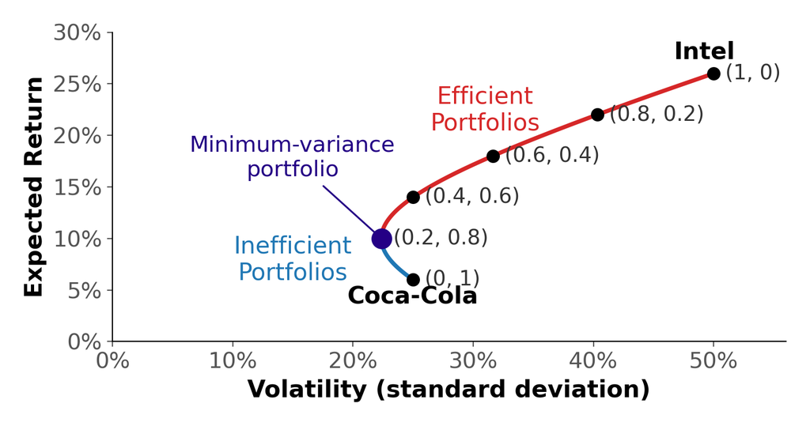

- The combination of the two stocks with the **lowest risk**: the leftmost point, the “nose” where the curve turns back. Here (0.2, 0.8), with 22.4% volatility, below either stock alone (25% and 50%).
- The **efficient set begins here**: above it the curve is efficient, below it every portfolio is dominated.
- It **ignores expected returns**: its weights depend only on volatilities and correlation. The most cautious investor picks it without looking at returns.

## The minimum variance portfolio

- We have the formula for the portfolio variance:

  $$\sigma^{2}_{p} = x_{1}^{2}\sigma^{2}_{1} + x_{2}^{2}\sigma^{2}_{2} + 2x_{1}x_{2}\,\sigma_{1}\sigma_{2}\rho_{1,2}$$
- By definition the two weights add up to one, $x_{1} + x_{2} = 1$, so $x_{2} = 1 - x_{1}$. Replacing $x_{2}$ in the formula leaves a single unknown, $x_{1}$:

  $$\sigma^{2}_{p} = x_{1}^{2}\sigma^{2}_{1} + \left(1-x_{1}\right)^{2}\sigma^{2}_{2} + 2x_{1}\left(1-x_{1}\right)\sigma_{1}\sigma_{2}\rho_{1,2}$$
- The minimum variance portfolio is the value of $x_{1}$ that makes this expression as small as possible:

  $$\min_{x_{1}} \ \sigma^{2}_{p}$$

## The minimum variance portfolio (con’t)

- Take the derivative with respect to $x_{1}$ and set it to zero (the first-order condition):

  $$2x_{1}\sigma^{2}_{1} - 2\left(1-x_{1}\right)\sigma^{2}_{2} + 2\sigma_{1}\sigma_{2}\rho_{1,2} - 4x_{1}\sigma_{1}\sigma_{2}\rho_{1,2} = 0$$
- Solve for $x_{1}$:

  $$x_{1} = \frac{\sigma^{2}_{2}-\sigma_{1}\sigma_{2}\rho_{1,2}}{\sigma^{2}_{1}+\sigma^{2}_{2}-2\sigma_{1}\sigma_{2}\rho_{1,2}}
  \qquad\qquad x_{2} = 1 - x_{1}$$
- Only volatilities and the correlation appear: the expected returns play no role. Check with Intel and Coca-Cola ($\rho_{1,2} = 0$): $x_{1} = 0.25^{2} / (0.5^{2} + 0.25^{2}) = 0.2$, the portfolio (0.2, 0.8).

## Short sales: a reminder from Lecture 2

- A **short sale** is selling a stock you do not own. You borrow the share (in practice from your broker), sell it today, and buy it back later to return it. You hold the cash now and owe one share later.
- You **gain if the price falls**: sell at 100, buy back at 60, return the share, keep 40. You **lose if it rises**: buying back at 150 costs you 50. And there is no ceiling on the loss, because a price can keep rising.
- In the portfolio formula a short sale is a **negative weight**. Short EUR 50 of stock 1 and put EUR 150 into stock 2: $x_{1} = -0.5$, $x_{2} = 1.5$, still adding up to 1. The return and variance formulas do not change.
- Why it matters here: negative weights **widen the set of portfolios** we can build.

## Short sales: an example, step by step

- **Today.** You borrow one share of Stock A, worth 100, and sell it. You now hold 100 in cash and owe one share. You put the 100 in the risk-free asset at 5% for one year.
- **In one year.** Two things happen at once:
  - Your risk-free investment has grown to $100 \times 1.05 = 105$.
  - You must buy one share of A to return it. Its price is $100 \times (1 +$ return of A$)$: if A rose 10%, buying it back costs 110; if it fell 20%, only 80.
- **Your gain or loss** is what you have (105) minus what you must pay to buy the share back.

## Short sales: an example, step by step (con’t)

| Return of Stock A | 10% | 0% | -10% | -20% |
| --- | --- | --- | --- | --- |
| Cash from the risk-free asset | 105 | 105 | 105 | 105 |
| Cost of buying the share back | 110 | 100 | 90 | 80 |
| **Gain/loss** (cash minus cost) | -5 | 5 | 15 | 25 |

- Read down a column: when A **rises** 10%, buying it back costs 110, more than the 105 you have, so you lose 5. When A **falls** 20%, buying it back costs only 80, so you keep 25.
- The short position is worth **minus** the price of the share: a short sale is a **negative weight** in Stock A. The lower A goes, the more you gain.

## Return of a portfolio with short sales

- Jérôme has 20 000 EUR available to invest for one year.
- He decides to sell short for a total of 10 000 EUR Coca-Cola stocks to buy Intel stocks for a total of 30 000 EUR
  - Remark: we still assume that the correlation between the two stocks is zero.
- What is the expected return and the volatility of his portfolio?

## Return of a portfolio with short sales: solution

- **Weights.** Jérôme’s own money is 20 000. He holds 30 000 of Intel and owes 10 000 of Coca-Cola:

  $$x_{I} = \frac{30\,000}{20\,000} = 1.5 \qquad x_{C} = \frac{-10\,000}{20\,000} = -0.5 \qquad x_{I} + x_{C} = 1$$
- **Expected return.** Same formula as before; the negative weight simply subtracts Coca-Cola’s return:

  $$E[R_{p}] = 1.5 \times 26\% + (-0.5) \times 6\% = 39\% - 3\% = 36\%$$

## Return of a portfolio with short sales: solution (con’t)

- **Variance and volatility.** Zero correlation, so the covariance term is zero; the negative weight is squared, so it still adds risk:

  $$\text{Var}(R_{p}) = 1.5^{2} \times 0.5^{2} + (-0.5)^{2} \times 0.25^{2} = 0.5625 + 0.0156 = 0.578$$

  $$\sigma_{p} = \sqrt{0.578} = 76\%$$
- More return than Intel alone (36% vs 26%) but much more risk (76% vs 50%): short selling extends the curve beyond Intel, as the next figure shows.

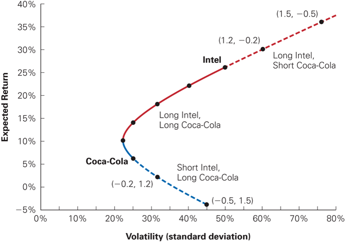

## B. $N$ risky stocks: the efficient frontier

- What happens to the curve when we add a **third stock** to Intel and Coca-Cola?
- Meet **Bore Industries**: expected return only 2%, the same 25% volatility as Coca-Cola, and **uncorrelated** with both. On its own it is a poor investment, dominated by Coca-Cola.
- Yet adding it helps. Any pair of stocks gives a curve; mixing Bore with a 50/50 Intel-Coca-Cola portfolio gives a **new curve that lies to the left** of the old one: the same returns at lower risk. Bore’s returns are unrelated to the other two, so part of its risk cancels out in the mix.
- With three stocks we are no longer limited to a curve: every combination is now possible, and the portfolios fill a whole **region**. The efficient frontier is the **upper-left edge** of that region, further left than the two-stock curve.
- Each extra stock pushes the frontier further left. The next slides show the three-stock case, then three stocks versus ten.

## Expected return and volatility for selected portfolios of Intel, Coca-Cola, and Bore Industries stocks

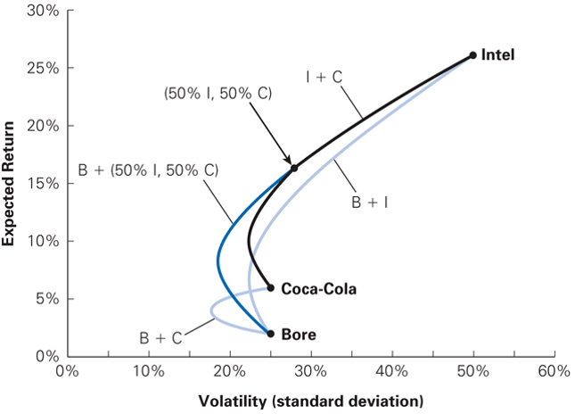

## Volatility and expected return for all portfolios of Intel, Coca-Cola, and Bore stock

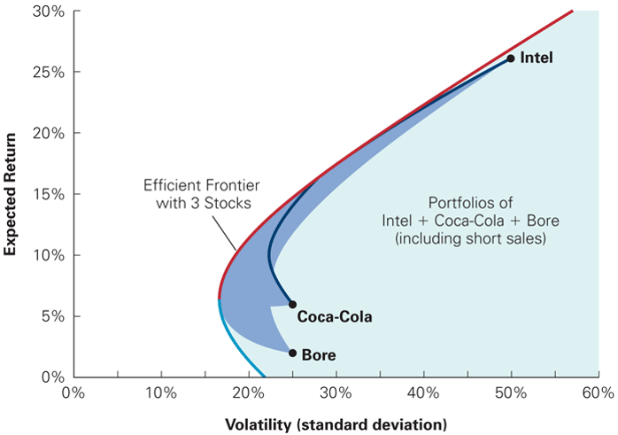

## Efficient frontier with three versus ten stocks

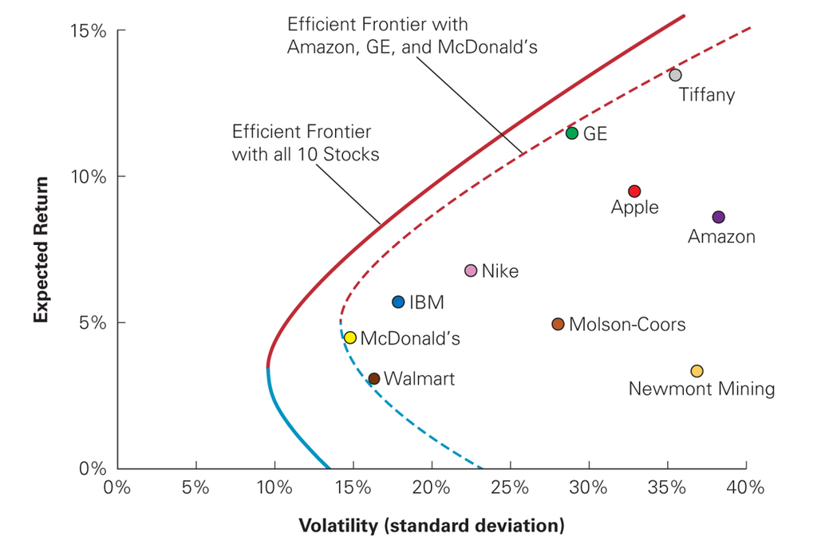

Each stock added moves the frontier left: the same return at a lower risk.

## Summary on efficient portfolios

- A portfolio is **efficient** when no other portfolio offers more return for the same risk, or less risk for the same return.
- The **efficient frontier** is the set of all efficient portfolios: the upper-left edge of the region of possible portfolios.
- **More stocks, better frontier.** Every stock we add, even a poor one on its own, moves the frontier further left. The best frontier uses all available investments.
- Efficient portfolios may include **short positions**.
- One thing is still missing: so far every portfolio is made only of **risky** stocks. What if we can also lend or borrow at a risk-free rate?

## Portfolio variance with $N$ stocks

With more stocks the formula is the same, only longer. For three stocks:

$$\text{Var}\left(R_{p}\right) = \underbrace{x_{1}^{2}\sigma_{1}^{2} + x_{2}^{2}\sigma_{2}^{2} + x_{3}^{2}\sigma_{3}^{2}}_{\text{own risk of each stock}}$$

$$+\ \underbrace{2x_{1}x_{2}\sigma_{1,2} + 2x_{1}x_{3}\sigma_{1,3} + 2x_{2}x_{3}\sigma_{2,3}}_{\text{how the stocks move together}}$$

- **Own risk**: one term per stock, its weight squared times its variance.
- **Comovement**: one term for every *pair* of stocks, where $\sigma_{1,2}$ is the covariance between stocks 1 and 2, counted twice.

With 3 stocks: 3 variance terms and 3 pairs. With 50 stocks: 50 variance terms and 1,225 pairs. **In a large portfolio the risk comes mostly from the covariances**, not from each stock’s own variance.

## Portfolio variance with $N$ stocks (con’t)

$$\text{Var}\left(R_{p}\right) = \sum_{i=1}^{N}\sum_{j=1}^{N} x_{i}\,x_{j}\,\sigma_{i,j}$$

In words: for every pair of stocks $i$ and $j$, multiply their two weights by their covariance, then add up. Written out:

$$\text{Var}\left(R_{p}\right) = x_{1}^{2}\sigma_{1}^{2} + \cdots + x_{N}^{2}\sigma_{N}^{2} \; + \; 2x_{1}x_{2}\sigma_{1,2} + 2x_{1}x_{3}\sigma_{1,3} + \cdots + 2x_{N-1}x_{N}\sigma_{N-1,N}$$

Those pairs fit in a square table, one row and one column per stock. **The variance is the sum of all its cells.**

|  | **Stock 1** | **Stock 2** | **Stock 3** | $\cdots$ | **Stock N** |
| --- | --- | --- | --- | --- | --- |
| **Stock 1** | $x_{1}^{2}\sigma_{1}^{2}$ | $x_{1}x_{2}\sigma_{1,2}$ | $x_{1}x_{3}\sigma_{1,3}$ | $\cdots$ | $x_{1}x_{N}\sigma_{1,N}$ |
| **Stock 2** | $x_{2}x_{1}\sigma_{1,2}$ | $x_{2}^{2}\sigma_{2}^{2}$ | $x_{2}x_{3}\sigma_{2,3}$ | $\cdots$ | $x_{2}x_{N}\sigma_{2,N}$ |
| **Stock 3** | $x_{3}x_{1}\sigma_{1,3}$ | $x_{3}x_{2}\sigma_{2,3}$ | $x_{3}^{2}\sigma_{3}^{2}$ | $\cdots$ | $x_{3}x_{N}\sigma_{3,N}$ |
| $\vdots$ |  |  |  |  |  |
| **Stock N** | $x_{N}x_{1}\sigma_{1,N}$ | $x_{N}x_{2}\sigma_{2,N}$ | $x_{N}x_{3}\sigma_{3,N}$ | $\cdots$ | $x_{N}^{2}\sigma_{N}^{2}$ |

- **The diagonal** ($N$ cells): each stock paired with itself, so the cell is its own variance. These are the first terms of the formula.
- **Off the diagonal** ($N^{2}-N$ cells): the covariances, each pair appearing twice, which is where the $2$ in front of each covariance term comes from. In a large portfolio these cells are the vast majority: **they decide the risk**.

## C. Adding a risk-free asset

- Besides diversifying, there is a second way to control risk: keep part of the money in a **risk-free asset**, such as a bank deposit or Treasury bills.
- Its return, the **risk-free rate** $r_{f}$, is known in advance: zero volatility, and zero correlation with every stock.
- We can also do the reverse: **borrow** at $r_{f}$ and invest more than our own money in risky assets. This is called **leverage**, or buying on margin.
- The question for this section: what do the possible portfolios look like once we mix a risky investment with the risk-free asset? We start with a simple example due to James Tobin (1958).

## Tobin’s example: two investments

Next year is either sunny or rainy, each with probability one half.

- **Umbrella Inc.** loses money in the sun and makes money in the rain.
- A **bank deposit** pays 3% whatever the weather.

| Investment | Sun | Rain | Expected return | Volatility |
| --- | --- | --- | --- | --- |
| Umbrella | $-10\%$ | $+30\%$ | $10\%$ | $20\%$ |
| Deposit | $+3\%$ | $+3\%$ | $3\%$ | $0\%$ |

- Umbrella: expected return $0.5 \times (-10\%) + 0.5 \times 30\% = 10\%$; each outcome is 20 points from it, so the volatility is $20\%$.
- The deposit has no risk but a much lower return. Can we get something in between? Can we get *more* than Umbrella?

## Step 1: 50 in Umbrella, 50 in the bank

- You have 100. Put 50 in Umbrella and 50 in the deposit: weights $x_{U} = 0.5$ and $x_{f} = 0.5$.
- Return in each state, then its mean and spread:

| State | Portfolio return |
| --- | --- |
| Sun | $0.5 \times (-10\%) + 0.5 \times 3\% = -3.5\%$ |
| Rain | $0.5 \times 30\% + 0.5 \times 3\% = 16.5\%$ |

$$E[R_{p}] = \frac{-3.5\% + 16.5\%}{2} = 6.5\% \qquad\qquad \sigma_{p} = 10\%$$

- Both numbers sit exactly **halfway** between the deposit (3%, 0%) and Umbrella (10%, 20%). Half the money in the risky asset gives half its risk and half its risk premium.

## What is leverage?

- **Leverage is investing with borrowed money**: you put in part of the amount and borrow the rest, so you control a position bigger than your own cash.
- Everyday example: a EUR 300,000 flat bought with EUR 60,000 of your own money and a EUR 240,000 mortgage. You put up 20% of the price but you get 100% of its moves: if the flat gains 10%, your 60,000 gains 50%; if it loses 10%, half your money is gone. Firms do the same with debt, funds with margin loans.
- The interest is owed whatever happens, so leverage **magnifies gains and losses alike**. It does not make an investment better, it scales it up.
- In our framework nothing new is needed: borrowing at $r_{f}$ is simply a **negative weight on the risk-free asset**, $x_{f} < 0$, with the weight on the risky asset above 1. The weights still add up to 1, and the same return and risk formulas apply.

## Step 2: borrow 50 and put 150 in Umbrella

- Now borrow 50 from the bank at 3% and invest 150 in Umbrella: weights $x_{U} = 1.5$ and $x_{f} = -0.5$. Borrowing is a **negative weight** in the risk-free asset.

| State | Portfolio return |
| --- | --- |
| Sun | $1.5 \times (-10\%) - 0.5 \times 3\% = -16.5\%$ |
| Rain | $1.5 \times 30\% - 0.5 \times 3\% = 43.5\%$ |

$$E[R_{p}] = \frac{-16.5\% + 43.5\%}{2} = 13.5\% \qquad\qquad \sigma_{p} = 30\%$$

- More expected return than Umbrella alone (13.5% vs 10%), but also more risk (30% vs 20%). **Leverage scales both up** in the same proportion: 1.5 times the risk, 1.5 times the risk premium.

## All the combinations lie on a straight line

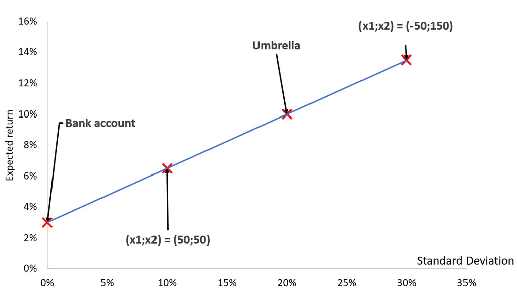

- With a fraction $x$ in Umbrella and $1 - x$ in the bank: $E[R_{p}] = r_{f} + x \left( E[R_{U}] - r_{f} \right)$ and $\sigma_{p} = x \, \sigma_{U}$.
- Both grow in proportion to $x$, so every mix is a point on the **straight line** from the deposit through Umbrella: lending puts you between the two, borrowing ($x > 1$) beyond Umbrella.

## The slope of the line is the Sharpe ratio

- On the previous slide, $E[R_{p}] = r_{f} + x\,(E[R_{U}] - r_{f})$ and $\sigma_{p} = x\,\sigma_{U}$. Replace $x$ by $\sigma_{p} / \sigma_{U}$:

  $$E[R_{p}] = r_{f} + \underbrace{\frac{E[R_{U}] - r_{f}}{\sigma_{U}}}_{\text{slope}} \times \sigma_{p}$$
- The slope is the **extra return you earn for each unit of risk you take**. It has a name: the **Sharpe ratio** of the risky investment.

  $$\text{Sharpe ratio} = \frac{\text{Excess return}}{\text{Volatility}} = \frac{E[R] - r_{f}}{\sigma}$$
- Umbrella: $(10\% - 3\%) / 20\% = 0.35$. Every 1% of volatility buys 0.35% of return above the risk-free rate.

## Comparing risky investments: compare the lines

- Once a risk-free asset exists, we can combine **any** portfolio on the efficient frontier with it. Each gives a straight line from the risk-free point: many lines to choose from (risk-free rate 3%):

| Portfolio | Expected return | Volatility | Sharpe ratio |
| --- | --- | --- | --- |
| Coca-Cola (0, 1) | 6% | 25% | 0.12 |
| (0.2, 0.8) | 10% | 22.4% | 0.31 |
| (0.5, 0.5) | 16% | 28% | 0.46 |
| Intel (1, 0) | 26% | 50% | 0.46 |

- The Sharpe ratio is the extra return **per unit of risk**: 0.46% per 1% of risk for Intel, only 0.12% for Coca-Cola.
- Take the **highest Sharpe ratio** and mix it with the risk-free asset: at any risk, it pays more than any other mix, whoever you are.
- Leverage makes any return possible, so **compare Sharpe ratios, not returns**.

## Two lines on the Intel-Coca-Cola curve

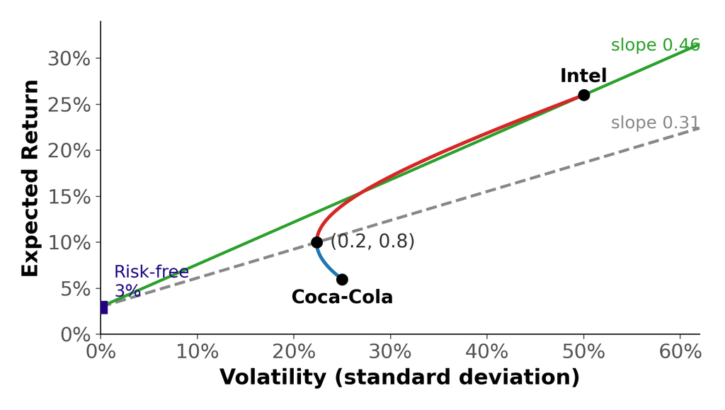

The line through Intel (slope 0.46) is above the line through (0.2, 0.8) (slope 0.31) everywhere. Mixing Intel with the risk-free asset beats mixing (0.2, 0.8) with it, at every level of risk.

## The best line: tangent to the frontier

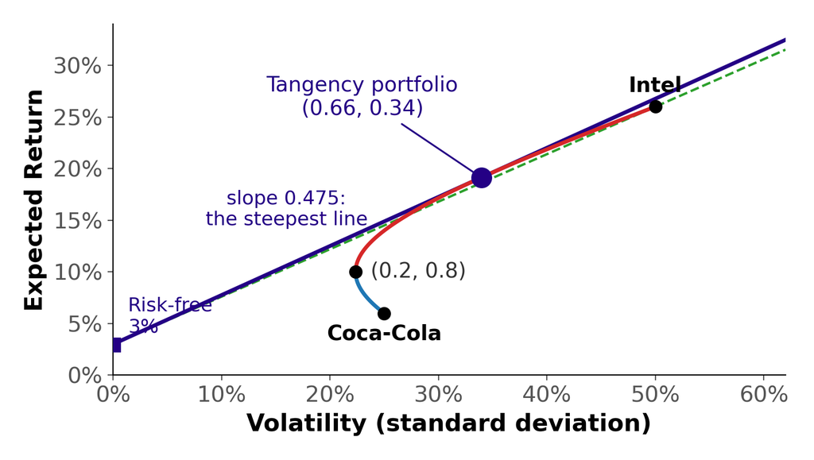

Rotate the line upward until it just touches the curve. The touching point is the **tangency portfolio**: (0.66, 0.34), return 19.1%, volatility 34%, Sharpe ratio 0.475, the highest available. Every other line lies below it.

## Everyone holds the same risky portfolio

- The tangency line beats every other line, so **no investor wants a different risky portfolio**. The tangency portfolio is the one efficient portfolio of risky assets.
- Risk aversion decides only **where on the line** you sit:
  - cautious investors put part of their money in the tangency portfolio and lend the rest at $r_{f}$: between the risk-free point and $T$;
  - bold investors borrow at $r_{f}$ and put more than their own money in $T$: beyond $T$ on the line.
- This is the **two-fund separation** theorem (James Tobin, 1958): every investor holds the same two funds, the tangency portfolio and the risk-free asset, in different proportions. The choice of the risky portfolio is objective; only the mix is personal.

## The general picture

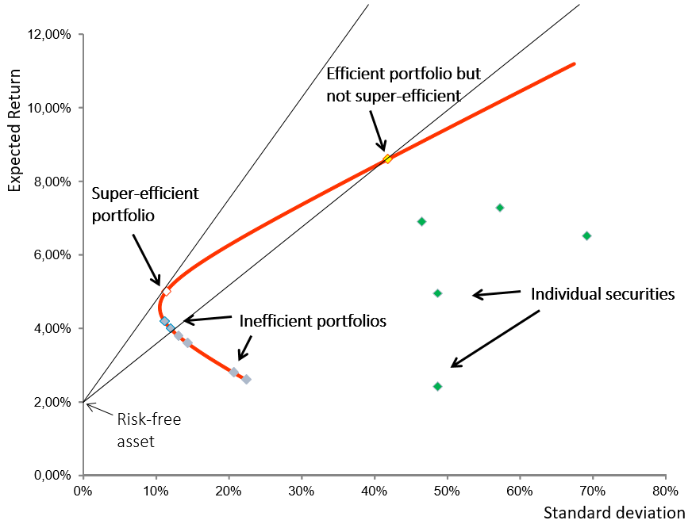

With many securities the story is the same: the Markowitz curve, the risk-free point, and one tangency portfolio (also called “super-efficient”). Every other portfolio on the curve stops being efficient once the risk-free asset exists.

## The efficient frontier is now a straight line

- Every efficient portfolio is a mix of the risk-free asset and the tangency portfolio $T$, so it sits on the tangent line. Its equation:

  $$E\left(R_{p}\right) = r_{f} + \underbrace{\frac{E\left(R_{T}\right) - r_{f}}{\sigma_{T}}}_{\text{Sharpe ratio of } T} \times \sigma_{p}$$
- Read it as: **risk-free rate, plus a risk premium proportional to the risk you take**. The proportion is the Sharpe ratio of the tangency portfolio, the same for everyone.
- With Intel and Coca-Cola: $E(R_{p}) = 3\% + 0.475 \times \sigma_{p}$. The old curve is dominated everywhere except at $T$.

## Example: moving to the tangent line

- An investor holds (0.2, 0.8): return 10%, volatility 22.4%. Two ways to do better using the tangency portfolio $T$ (19.1%, 34%) and the risk-free asset:
- **Same risk, more return.** Put a fraction $x$ in $T$ with $x \times 34\% = 22.4\%$, so $x = 0.66$, the rest at $r_{f}$:

  $$E[R_{p}] = 3\% + 0.66 \times (19.1\% - 3\%) = 13.6\% \qquad \text{instead of } 10\%$$
- **Same return, less risk.** Choose $x$ so that $3\% + x \times 16.1\% = 10\%$, so $x = 0.43$:

  $$\sigma_{p} = 0.43 \times 34\% = 14.7\% \qquad \text{instead of } 22.4\%$$
- Either way the investor ends up on the tangent line, holding only $T$ and the risk-free asset.

## Two types of risk

1. **Systematic risk**: common to all securities.

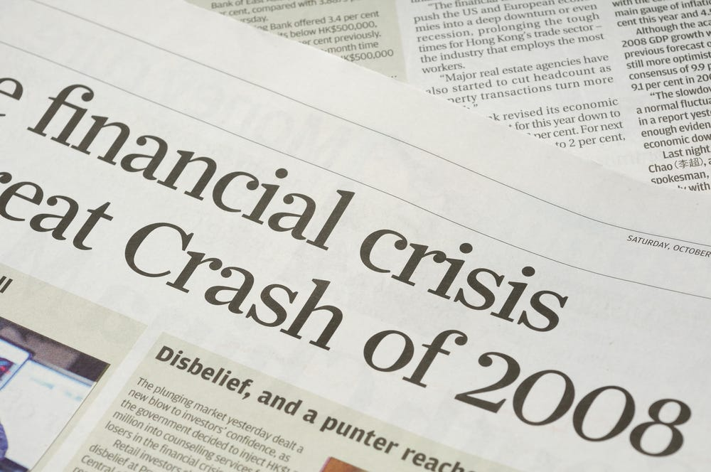

2. **Idiosyncratic risk**: specific to one security.

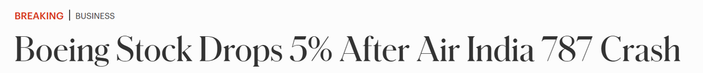

## Diversification and risk

- Which risk do investors reduce by diversifying their portfolios?
  - The **systematic** risk? [risk common to all securities]
  - The **idiosyncratic** risk? [risk specific to a particular security]
- Remark: the variance of any portfolio can be written as
  $$\sigma^{2}_{p} = \sum^{N}_{i=1} x^{2}_{i} \sigma^{2}_{i} + \sum^{N}_{i=1} \sum^{N}_{\overset{j=1}{j\ne i}} x_{i} x_{j}\text{Cov}\left[R_{i},R_{j} \right].$$
- Not clear? Take $x_{i} = 1/N$ (equally-weighted portfolio)

## Diversification and risk: a simple example

Volatility of an equally-weighted portfolio versus the number of stocks

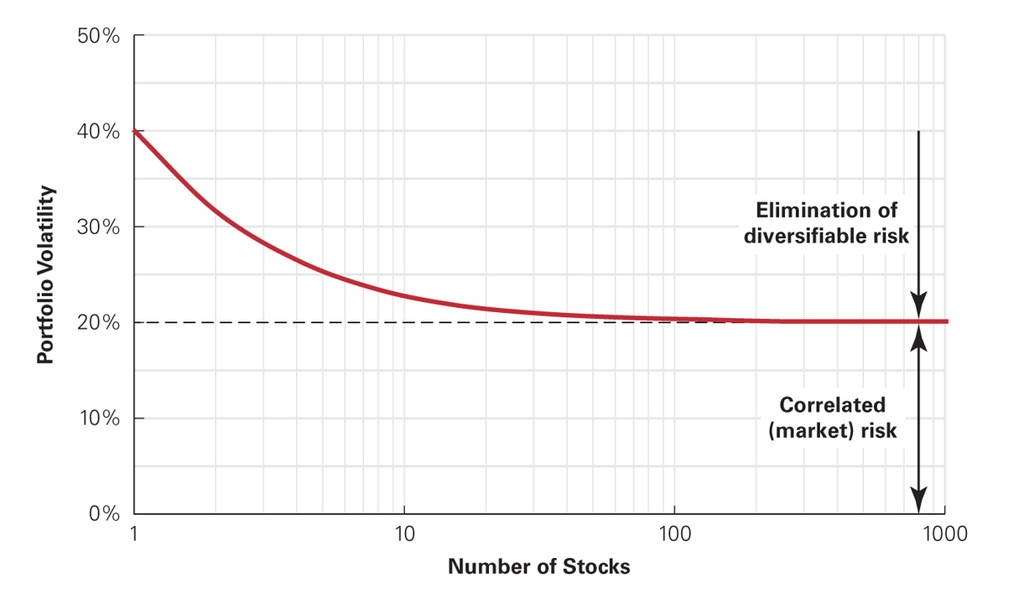

## Diversification and risk: summary

Common risk Market-wide: economic conditions, interest and exchange rates, inflation, … **The asset is affected by the evolution of the market** (with its own sensitivity)

Independent risk Specific to the firm/security i : product market, quality of the management, operational risk, …

$\downarrow$

**Systematic** risk = **Undiversifiable** risk (market risk)

$\downarrow$

**Idiosyncratic** risk = **Diversifiable** risk

## Exercise 1: one risky asset and a risk-free asset

- Stock A trades today at EUR 100. In one year it will be worth **120** if the economy expands (probability 0.5) or **100** in a recession (probability 0.5).
- The risk-free rate is 5%.
- The fund **AlwaysMore** claims to offer a product superior to Stock A. For an initial investment of **220** it commits to pay in one year **320** in the expansion and **200** in the recession.
1. What are the expected return, the volatility and the Sharpe ratio of Stock A?
2. Same three numbers for the AlwaysMore product, at its price of 220.
3. Is the product superior to Stock A? Can you do better on your own?
4. What is the highest price you would pay for the product?

## Exercise 1, question 1: Stock A

- **Return in each state.** Expansion: $120/100 - 1 = +20\%$. Recession: $100/100 - 1 = 0\%$.
- **Expected return**: the average of the two, each with probability one half:

  $$E(R_{A}) = 0.5 \times 20\% + 0.5 \times 0\% = 10\%$$
- **Volatility**: each outcome is 10 points from the mean, so the variance is 100 and $\sigma_{A} = \sqrt{100} = 10\%$.
- **Sharpe ratio**: extra return over the risk-free rate, per unit of risk:

  $$\frac{E(R_{A}) - r_{f}}{\sigma_{A}} = \frac{10\% - 5\%}{10\%} = 0.50$$

## Exercise 1, question 2: the AlwaysMore product

- Same steps, starting from the price of 220.
- **Return in each state.** Expansion: $320/220 - 1 = +45.5\%$. Recession: $200/220 - 1 = -9.1\%$.
- **Expected return**: $0.5 \times 45.5\% + 0.5 \times (-9.1\%) = 18.2\%$.
- **Volatility**: each outcome is 27.3 points from the mean, so $\sigma = 27.3\%$.
- **Sharpe ratio**:

  $$\frac{18.2\% - 5\%}{27.3\%} = 0.48$$
- More return than Stock A, but much more risk. The Sharpe ratio tells us whether the extra return pays for the extra risk.

## Exercise 1, question 3: is the product superior?

- **Compare Sharpe ratios.** Stock A: 0.50. AlwaysMore: 0.48. The product pays **less** extra return per unit of risk. It is not superior.
- **Do it yourself.** Lecture 3 showed that leverage on Stock A moves you along the line with slope 0.50. To reach the product’s risk of 27.3%, put $x = 27.3 / 10 = 2.73$ times your money in Stock A, borrowing the rest at 5%:

  $$E(R) = 5\% + 2.73 \times (10\% - 5\%) = 18.6\%$$
- Same risk as the product, 18.6% against 18.2%. **Borrowing to buy Stock A beats AlwaysMore.** Reject the offer at 220.

## Exercise 1, question 4: the highest price

- The product is just a bundle of Stock A and borrowing. Find the bundle that pays exactly 320 and 200: buy $a$ shares of A and put $b$ in the risk-free asset (negative $b$ means borrowing).

  $$\begin{aligned}
  \text{Expansion: } & 120\,a + 1.05\,b = 320 \\
  \text{Recession: } & 100\,a + 1.05\,b = 200
  \end{aligned}$$
- Subtract the second line from the first: $20\,a = 120$, so $a = 6$ shares. Then $1.05\,b = 200 - 600 = -400$, so $b = -381$: borrow 381.
- **Cost of the bundle today**: 6 shares at 100, minus the 381 borrowed, is **EUR 219**. The bundle pays exactly what the product pays, so 219 is the most the product is worth.
- AlwaysMore asks 220, one euro more than it costs to build yourself. At 219 its Sharpe ratio would be exactly 0.50, the same as Stock A.

## Exercise 2: Optimal Portfolio Choice with two risky assets

- You want to form a portfolio with two stocks A and B. These stocks have expected returns of $E_A =10\%$ and $E_B =15\%$ with standard deviations of $\sigma_{A} = 15\%$ and $\sigma_{B} = 25\%$. The correlation coefficient between the two stocks is $-0.3$.
1. What is the risk and return of a portfolio invested to 40% in A and 60% in B?
2. If you want to achieve an expected return of 11%, how much risk do you need to take?
3. Suppose that you can invest in the two stocks and also invest and borrow at the risk-free rate of 5%. Show that you can construct a portfolio with the same return than stock A but with a lower risk.

## Exercise (diversification)

- You can invest in two stocks with the following characteristics

  | Stock | Expected Return | St.Dev. |
  | --- | --- | --- |
  | A | 12% | 15% |
  | B | 20% | 45% |

- What is the risk and the return of a portfolio invested to 50% in A and 50% in B if the correlation coefficient is 0.2?
- If the stocks are perfectly negatively correlated, what is the portfolio with the lowest risk?

## Quiz

- Define the leverage effect
- Define the diversification effect
- Is it possible to augment the return of a portfolio with the risk-free asset?
  - What happens then to the risk of the portfolio?
- If the stocks are not perfectly correlated, then the risk of the portfolio is always: a) lower, b) larger c) equal to the weighted average of the individual risks?

## Quiz

- Is it possible to fix the level of risk of a portfolio and how?
- Is it possible to fix the level of expected return of a portfolio and how?
- In which case can it be advantageous to buy a stock with higher risk and lower expected return?
- What are short sales?
- What are you betting on in the case of a short sale?
- What does a short position correspond to in terms of portfolio weight?